# Random Forests en R

# 1. Introducción

- Vimos que el bagging y los random forests son extensiones de los árboles de decisión
- Son ejemplos de los métodos de ensamble
- Bajo los cuales estimamos varios modelos de un mismo tipo y promediamos para obtener mejores predicciones
- En este caso, contruimos varios árboles de decisión, cada uno de una muestra bootstrap diferente del conjunto de datos de entrenamiento
- La diferencia entre bagging y random forests es que en el segundo caso, en cada árbol y nodo de decisión, usamos un subconjunto de las características de interés
- Veamos la diferencia entre los tres métodos con un ejemplo del sector bancario
- Contamos con información de la reacción de un gran número de clientes tras la llamada del banco a ofrecer un producto
- En este caso, un depósito a plazo
- Los clientes pueden adquirir o no el producto
- Nos interesa predecir qué tipo de clientes tienden a aceptar
- Esto nos puede ayudar a enfocar mejor nuestros recursos a dichos clientes

# 2. Datos

- Usaremos la base `bank.csv`, que es una versión modificada extraída de https://archive.ics.uci.edu/ml/datasets/Bank+Marketing
- Los datos corresponden a una campaña directa de marketing de una institución bancaria portuguesa
- Se busca predecir si un cliente adquiere un depósito a plazo luego de que se le ofrece telefónicamente
- Carguemos los datos. Como siempre, no olviden fijar el directorio de trabajo

```r
bank <- read.csv("bank.csv")
```

- Inspeccionemos la base. Primero, qué variables tiene:

```r
names(bank)
```

```
##  [1] "age"          "job"          "marital"      "education"
##  [5] "default"      "housing"      "loan"         "contact"
##  [9] "month"        "day_of_week"  "duration"     "campaign"
## [13] "previous"     "poutcome"     "empvarrate"   "conspriceidx"
## [17] "consconfidx"  "euribor3m"    "nremployed"   "y"
```

- Y la estructura de los datos

```r
str(bank)
```

```
## 'data.frame':    41188 obs. of  20 variables:
##  $ age         : int  56 57 37 40 56 45 59 41 24 25 ...
##  $ job         : Factor w/ 12 levels "admin.","blue-collar",..: 4 8 8 1 8 8 1 2 10 8 ...
##  $ marital     : Factor w/ 4 levels "divorced","married",..: 2 2 2 2 2 2 2 2 3 3 ...
##  $ education   : Factor w/ 8 levels "basic.4y","basic.6y",..: 1 4 4 2 4 3 6 8 6 4 ...
##  $ default     : Factor w/ 3 levels "no","unknown",..: 1 2 1 1 1 2 1 2 1 1 ...
##  $ housing     : Factor w/ 3 levels "no","unknown",..: 1 1 3 1 1 1 1 1 3 3 ...
##  $ loan        : Factor w/ 3 levels "no","unknown",..: 1 1 1 1 3 1 1 1 1 1 ...
##  $ contact     : Factor w/ 2 levels "cellular","telephone": 2 2 2 2 2 2 2 2 2 2 ...
##  $ month       : Factor w/ 10 levels "apr","aug","dec",..: 7 7 7 7 7 7 7 7 7 7 ...
##  $ day_of_week : Factor w/ 5 levels "fri","mon","thu",..: 2 2 2 2 2 2 2 2 2 2 ...
##  $ duration    : int  261 149 226 151 307 198 139 217 380 50 ...
##  $ campaign    : int  1 1 1 1 1 1 1 1 1 1 ...
##  $ previous    : int  0 0 0 0 0 0 0 0 0 0 ...
##  $ poutcome    : Factor w/ 3 levels "failure","nonexistent",..: 2 2 2 2 2 2 2 2 2 2 ...
##  $ empvarrate  : num  1.1 1.1 1.1 1.1 1.1 1.1 1.1 1.1 1.1 1.1 ...
##  $ conspriceidx: num  94 94 94 94 94 ...
##  $ consconfidx : num  -36.4 -36.4 -36.4 -36.4 -36.4 ...
##  $ euribor3m   : num  4.86 4.86 4.86 4.86 4.86 ...
##  $ nremployed  : num  5191 5191 5191 5191 5191 ...
##  $ y           : Factor w/ 2 levels "no","yes": 1 1 1 1 1 1 1 1 1 1 ...
```

- En total, 41188 y 20 variables. La última, `y`, es el outcome de interés

```r
prop.table(table(bank$y))
```

```
##
##        no       yes
## 0.8873458 0.1126542
```

- El 88.7% de los contactados no acepta el producto, frente a un 11.2% que sí
- Siempre es bueno entender las variables

```r
table(bank$marital)
```

```
##
## divorced  married   single  unknown
##     4612    24928    11568       80
```

```r
table(bank$education)
```

```
##
##            basic.4y            basic.6y            basic.9y
##                4176                2292                6045
##         high.school          illiterate professional.course
##                9515                  18                5243
##   university.degree             unknown
##               12168                1731
```

```r
summary(bank$age)
```

```
##    Min. 1st Qu.  Median    Mean 3rd Qu.    Max.
##   17.00   32.00   38.00   40.02   47.00   98.00
```

```r
table(bank$job)
```

```
##
##        admin.   blue-collar  entrepreneur     housemaid    management
##         10422          9254          1456          1060          2924
##       retired self-employed      services       student    technician
##          1720          1421          3969           875          6743
##    unemployed       unknown
##          1014           330
```

# 3. Árbol de Decisión

- Compararemos los resultados de bagging y random forests con los de un árbol de decisión
- Como la semana pasada, usamos el algoritmo C5.0 para esto (si no lo han instalado, recuerden llamar `install.packages("C50")`)

```r
library(C50)
```

- Creemos nuestras bases de entrenamiento y prueba
- Usaremos 37069 observaciones (el 90%) para entrenar el modelo
- Y 4119 (el 10%) para probarlo
- Aleatoriamente dividiremos la base total en entrenamiento y prueba
- Para ello, fijemos la semilla (para poder replicar)

```r
set.seed(123)
```

- La fijamos, arbitrariamente, en 123
- Creemos el vector aleatorio para dividir

```r
train_sample <- sample(41188, 37069)
```

- Creamos un vector con 37069 enteros aleatorios entre 1 y 41188
- Y las filas asociadas a esos números serán nuestra base de entrenamiento

```r
bank_train <- bank[train_sample, ]
bank_test <- bank[-train_sample, ]
```

- Las restantes filas componen la base de prueba
- Es bueno inspeccionar las bases:

```r
str(bank_train)
```

```
## 'data.frame':    37069 obs. of  20 variables:
##  $ age         : int  33 28 48 24 45 33 31 31 39 37 ...
##  $ job         : Factor w/ 12 levels "admin.","blue-collar",..: 7 8 5 9 1 1 8 8 1 1 ...
##  $ marital     : Factor w/ 4 levels "divorced","married",..: 3 2 2 3 3 1 1 2 2 2 ...
##  $ education   : Factor w/ 8 levels "basic.4y","basic.6y",..: 7 4 7 4 7 7 4 8 6 4 ...
##  $ default     : Factor w/ 3 levels "no","unknown",..: 1 1 1 1 1 1 1 1 1 1 ...
##  $ housing     : Factor w/ 3 levels "no","unknown",..: 2 3 3 1 2 1 3 3 1 3 ...
##  $ loan        : Factor w/ 3 levels "no","unknown",..: 2 1 3 1 2 1 3 1 1 1 ...
##  $ contact     : Factor w/ 2 levels "cellular","telephone": 2 1 2 1 1 2 1 1 1 2 ...
##  $ month       : Factor w/ 10 levels "apr","aug","dec",..: 5 7 4 5 8 7 2 5 2 4 ...
##  $ day_of_week : Factor w/ 5 levels "fri","mon","thu",..: 1 1 3 4 4 1 4 4 1 3 ...
##  $ duration    : int  38 237 154 253 133 279 242 98 306 29 ...
##  $ campaign    : int  5 4 1 1 3 1 3 3 3 14 ...
##  $ previous    : int  0 0 0 0 1 0 0 0 0 0 ...
##  $ poutcome    : Factor w/ 3 levels "failure","nonexistent",..: 2 2 2 2 1 2 2 2 2 2 ...
##  $ empvarrate  : num  1.4 -1.8 1.4 -2.9 -3.4 ...
##  $ conspriceidx: num  94.5 92.9 93.9 93 92.6 ...
##  $ consconfidx : num  -41.8 -46.2 -42.7 -40.8 -30.1 ...
##  $ euribor3m   : num  4.959 1.313 4.962 1.262 0.715 ...
##  $ nremployed  : num  5228 5099 5228 5076 5018 ...
##  $ y           : Factor w/ 2 levels "no","yes": 1 1 1 1 1 1 1 1 1 1 ...
```

```r
str(bank_test)
```

```
## 'data.frame':    4119 obs. of  20 variables:
##  $ age         : int  39 37 53 55 37 44 37 38 31 35 ...
##  $ job         : Factor w/ 12 levels "admin.","blue-collar",..: 5 1 1 11 1 2 1 10 1 1 ...
##  $ marital     : Factor w/ 4 levels "divorced","married",..: 3 2 3 2 2 3 2 3 1 2 ...
##  $ education   : Factor w/ 8 levels "basic.4y","basic.6y",..: 3 4 6 6 7 3 7 7 4 7 ...
##  $ default     : Factor w/ 3 levels "no","unknown",..: 2 1 1 2 1 1 2 1 1 1 ...
##  $ housing     : Factor w/ 3 levels "no","unknown",..: 1 3 1 3 1 3 3 1 1 3 ...
##  $ loan        : Factor w/ 3 levels "no","unknown",..: 1 1 1 3 1 1 1 3 1 1 ...
##  $ contact     : Factor w/ 2 levels "cellular","telephone": 2 2 2 2 2 2 2 2 2 2 ...
##  $ month       : Factor w/ 10 levels "apr","aug","dec",..: 7 7 7 7 7 7 7 7 7 7 ...
##  $ day_of_week : Factor w/ 5 levels "fri","mon","thu",..: 2 2 2 2 2 2 2 2 2 2 ...
##  $ duration    : int  195 172 179 145 232 91 214 20 246 180 ...
##  $ campaign    : int  1 1 1 1 1 1 1 1 1 2 ...
##  $ previous    : int  0 0 0 0 0 0 0 0 0 0 ...
##  $ poutcome    : Factor w/ 3 levels "failure","nonexistent",..: 2 2 2 2 2 2 2 2 2 2 ...
##  $ empvarrate  : num  1.1 1.1 1.1 1.1 1.1 1.1 1.1 1.1 1.1 1.1 ...
##  $ conspriceidx: num  94 94 94 94 94 ...
##  $ consconfidx : num  -36.4 -36.4 -36.4 -36.4 -36.4 ...
##  $ euribor3m   : num  4.86 4.86 4.86 4.86 4.86 ...
##  $ nremployed  : num  5191 5191 5191 5191 5191 ...
##  $ y           : Factor w/ 2 levels "no","yes": 1 1 1 1 1 1 1 1 1 1 ...
```

- Verifiquemos las proporciones de clientes que adquieren el producto en cada base:

```r
prop.table(table(bank_train$y))
```

```
##
##        no       yes
## 0.8868596 0.1131404
```

```r
prop.table(table(bank_test$y))
```

```
##
##        no       yes
## 0.8917213 0.1082787
```

- Prácticamente igual a lo que tenemos en la población, fruto de la aleatorización
- Con estas dos bases, podemos construir nuestro árbol de decisión:

```r
bank_tree <- C5.0(bank_train[-20], bank_train$y)
```

- Nótese que excluímos la columna 20, que corresponde al outcome de interés
- Obtengamos información del árbol

```r
bank_tree
```

```
##
## Call:
## C5.0.default(x = bank_train[-20], y = bank_train$y)
##
## Classification Tree
## Number of samples: 37069
## Number of predictors: 19
##
## Tree size: 313
##
## Non-standard options: attempt to group attributes
```

- Bastante grande el árbol
- De hecho lo podemos ver (aunque no es muy agradable hacerlo)

```r
summary(bank_tree)
```

```
##
## Call:
## C5.0.default(x = bank_train[-20], y = bank_train$y)
##
##
## C5.0 [Release 2.07 GPL Edition]      Tue Mar 14 01:37:01 2017
## -------------------------------
##
## Class specified by attribute `outcome'
##
## Read 37069 cases (20 attributes) from undefined.data
##
## Decision tree:
##
## poutcome = success:
## :...duration <= 164:
## :   :...campaign > 3: no (34/1)
## :   :   campaign <= 3:
## :   :   :...day_of_week in {fri,mon}: no (104/20)
## :   :       day_of_week in {thu,tue,wed}:
## :   :       :...nremployed > 5023.5: no (84/16)
## :   :           nremployed <= 5023.5:
## :   :           :...duration > 147: yes (21/2)
## :   :               duration <= 147:
## :   :               :...conspriceidx <= 93.444: yes (41/15)
## :   :                   conspriceidx > 93.444: no (20/3)
## :   duration > 164:
## :   :...nremployed <= 5076.2: yes (788/132)
## :       nremployed > 5076.2:
## :       :...duration > 410:
## :           :...day_of_week in {fri,tue}: no (17/7)
## :           :   day_of_week in {mon,thu,wed}: yes (48/7)
## :           duration <= 410:
## :           :...empvarrate > -1.1: no (14)
## :               empvarrate <= -1.1:
## :               :...job in {blue-collar,entrepreneur,housemaid,management,
## :                   :       retired,self-employed,student,
## :                   :       unknown}: no (34/4)
## :                   job in {services,technician}: yes (19/6)
## :                   job = admin.:
```

[output cut: 604 more lines]

```
##   26.28% euribor3m
##    7.67% contact
##    5.53% day_of_week
##    4.70% job
##    4.10% default
##    3.44% education
##    3.33% previous
##    2.08% campaign
##    1.83% conspriceidx
##    0.75% loan
##    0.75% marital
##    0.32% housing
##
##
## Time: 0.3 secs
```

- Más que el árbol, nos interesan dos cosas de este output
- La precisión en los datos de entrenamiento: una tasa de error de 6.5%
- Y la importancia de las variables
- Duración y outcome previo son las más importantes
- Recordemos que esta importancia se calcula de acuerdo con la ganancia en información que se logra al dividir en esas variables
- Se calcula la ganancia para cada variable y se divide por el valor de la que más ganancia produce
- Evaluamos el desempeño en la base de prueba, pronosticando y comparando

```r
bank_pred_tree <- predict(bank_tree, bank_test)
```

- Y comparemos, construyendo nuestras acostumbradas tablas

```r
library(gmodels)
```

```r
CrossTable(bank_test$y, bank_pred_tree, prop.chisq=FALSE, prop.c=FALSE, prop.r=FALSE, dnn=c("Real", "Pronostico"))
```

```
##
##
##    Cell Contents
## |-------------------------|
## |                       N |
## |         N / Table Total |
## |-------------------------|
##
##
## Total Observations in Table:  4119
##
##
##              | Pronostico
##         Real |        no |       yes | Row Total |
## -------------|-----------|-----------|-----------|
##           no |      3532 |       141 |      3673 |
##              |     0.857 |     0.034 |           |
## -------------|-----------|-----------|-----------|
##          yes |       228 |       218 |       446 |
##              |     0.055 |     0.053 |           |
## -------------|-----------|-----------|-----------|
## Column Total |      3760 |       359 |      4119 |
## -------------|-----------|-----------|-----------|
##
##
```

- Una tasa de error del 9%. Precisión del 91%
- En los clientes que no adquieren el producto, el modelo se equivoca el 3.8 % (141/3673)
- En los que sí lo adquieren, se equivoca el 51% (228/446)
- Una tasa alta esta última. Sobre todo que esta es la cantidad de interés
- Veamos si la podemos mejorar

# 4. Bagging

- Recordemos que bajo bagging hacemos bootstrap para obtener diferentes muestras con reemplazo de la base de entrenamiento
- Para cada muestra construimos un árbol de decisión
- Cada árbol hace su pronóstico. El pronóstico final para cada objeto a clasificar es el resultado de la regla de la mayoría entre todos los árboles
- Con el paquete `randomForest` podemos hacer bagging
- Porque en últimas bagging es un caso particular de random forests
- En el que se usan todas las características
- Si no lo han hecho, instalen el paquete: `install.packages("randomForest")`

```r
library(randomForest)
```

- En este caso, para hacer bagging usamos la función `randomForest` de dicho paquete: de la siguiente forma:

```r
bank_bag <- randomForest(x=bank_train[-20], y=bank_train$y, importance=TRUE, mtry=19)
```

- Llamamos al modelo `bank_bag`
- La base de entrenamiento nuevamente es `bank_train`, pero excluimos la columna 20, que corresponde al outcome
- El outcome sobre el que queremos predecir es `bank_train$y`
- Fijamos el parámetro `importance=TRUE` porque queremos calcular la importancia de las variables
- El parámetro `mtry` indica el número de variables a utilizar en cada árbol
- Lo fijamos en 19, que es el total de características que tenemos, para que sea un modelo de bagging
- Podemos obtener información del modelo:

```r
bank_bag
```

```
##
## Call:
##  randomForest(x = bank_train[-20], y = bank_train$y, mtry = 19,      importance = TRUE)
##                Type of random forest: classification
##                      Number of trees: 500
## No. of variables tried at each split: 19
##
##         OOB estimate of  error rate: 8.6%
## Confusion matrix:
##        no  yes class.error
## no  31513 1362  0.04142966
## yes  1825 2369  0.43514545
```

- La matriz de confusión se basa en las estimaciones de las muestras “out of bag” (OOB)

- Recordemos que cada árbol se construye con una muestra bootstrap
- Pero entonces para cada árbol hay un conjunto de casos que no forman parte de la muestra
- Sobre esos casos el árbol puede hacer una predicción
- Esas son las predicciones OOB de la matriz
- Un gráfica nos ayuda a entender mejor el modelo
- Los errores OOB en función del número de árboles

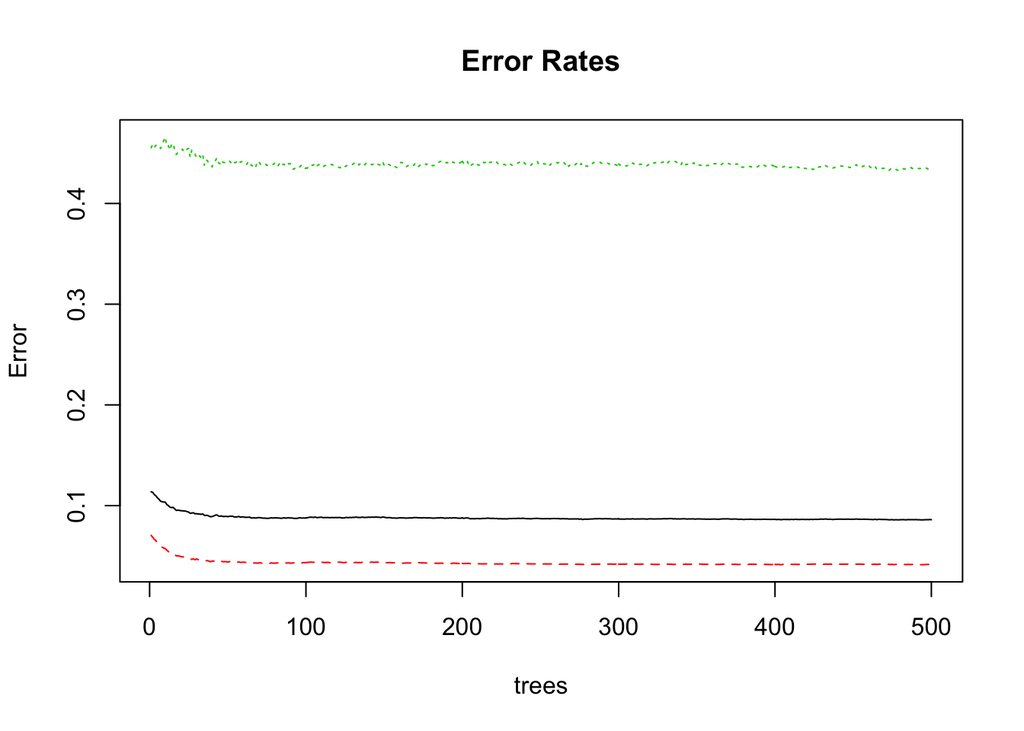

```r
plot(bank_bag, main = "Error Rates")
```

- La curva negra es la tasa total de errores OOB (8.6%)
- La roja la tasa de error en clientes que no adquieren el producto (4.1%)
- Y la verde en los clientes que sí lo adquieren (43.5%)
- Es claro que antes de los 100 árboles, las tasas se estabilizan
- También podemos estimar la importancia de las variables
- La función `importance()` nos da información al respecto

```r
round(importance(bank_bag, type=2),  2)
```

```
##              MeanDecreaseGini
## age                    650.92
## job                    467.42
## marital                105.82
## education              330.85
## default                 37.64
## housing                 77.44
## loan                    73.75
## contact                 45.47
## month                  284.99
## day_of_week            308.36
## duration              2552.21
## campaign               279.45
## previous               103.48
## poutcome               156.67
## empvarrate              29.74
## conspriceidx            89.62
## consconfidx             90.36
## euribor3m              579.25
## nremployed            1174.27
```

- Nos interesa el mean decrease in Gini. Que representa la ganancia en información promedio de cada variables
- Nótese que estos árboles usan el coeficiente de Gini en lugar del índice de entropía. La intuición es la misma
- A mayor valor, mayor importancia. Duración gana (aunque probablemente es la variable menos interesante desde un punto de vista práctico)
- También podemos ver esto gráficamente

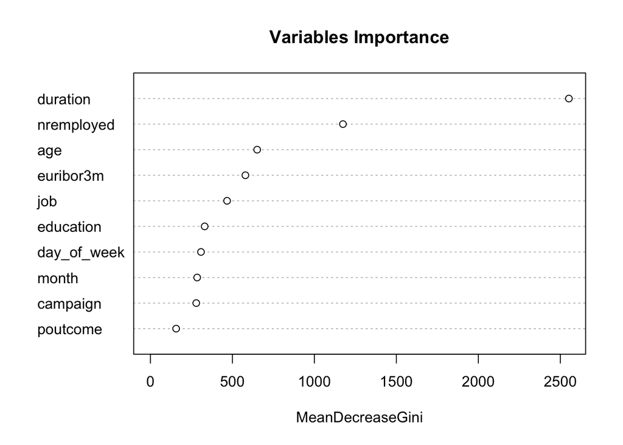

```r
varImpPlot(bank_bag, sort = TRUE, main="Variables Importance",type=2, n.var=10)
```

- Estas son las 10 variables que más ganancia en información generan (o que generan subconjuntos más puros)
- Naturalmente, nos interesa predecir sobre la base de prueba, como con los árboles:

```r
bank_pred_bag <- predict(bank_bag, bank_test)
```

- Y comparar realidad con predicciones

```r
CrossTable(bank_test$y, bank_pred_bag, prop.chisq=FALSE, prop.c=FALSE, prop.r=FALSE, dnn=c("real", 'pronostico'))
```

```
##
##
##    Cell Contents
## |-------------------------|
## |                       N |
## |         N / Table Total |
## |-------------------------|
##
##
## Total Observations in Table:  4119
##
##
##              | pronostico
##         real |        no |       yes | Row Total |
## -------------|-----------|-----------|-----------|
##           no |      3527 |       146 |      3673 |
##              |     0.856 |     0.035 |           |
## -------------|-----------|-----------|-----------|
##          yes |       221 |       225 |       446 |
##              |     0.054 |     0.055 |           |
## -------------|-----------|-----------|-----------|
## Column Total |      3748 |       371 |      4119 |
## -------------|-----------|-----------|-----------|
##
##
```

- La tasa de error ahora es de 8.9%. Una mejora ínfima respecto al árbol C5.0
- El error en los que no adquieren el producto es de 4% (146/3673)
- Y en los que sí de 49.6% (221/446). Una mejora leve

# 5. Random Forests

- Podemos mejorar las predicciones si usamos random forests en su lugar?
- Vimos que la diferencia es que random forests introduce una nueva fuente de variabilidad
- En cada árbol y cada nodo, se selecciona aleatoriamente un conjunto de variables sobre la cuáles decidir
- A diferencia del bagging, que usa todas las variables
- Naturalmente, con la función `randomForest()` corremos el modelo
- La diferencia es que no tenemos que especificar el número de variables (que antes habíamos fijado en 19)
- El default es usar `m=sqrt(p)`

```r
bank_rf <- randomForest(x=bank_train[-20], y=bank_train$y, importance=TRUE)
```

- Nuevamente, podemos obtener información del modelo

```r
bank_rf
```

```
##
## Call:
##  randomForest(x = bank_train[-20], y = bank_train$y, importance = TRUE)
##                Type of random forest: classification
##                      Number of trees: 500
## No. of variables tried at each split: 4
##
##         OOB estimate of  error rate: 8.53%
## Confusion matrix:
##        no  yes class.error
## no  31636 1239  0.03768821
## yes  1923 2271  0.45851216
```

- Graficar la evolución de los errores:

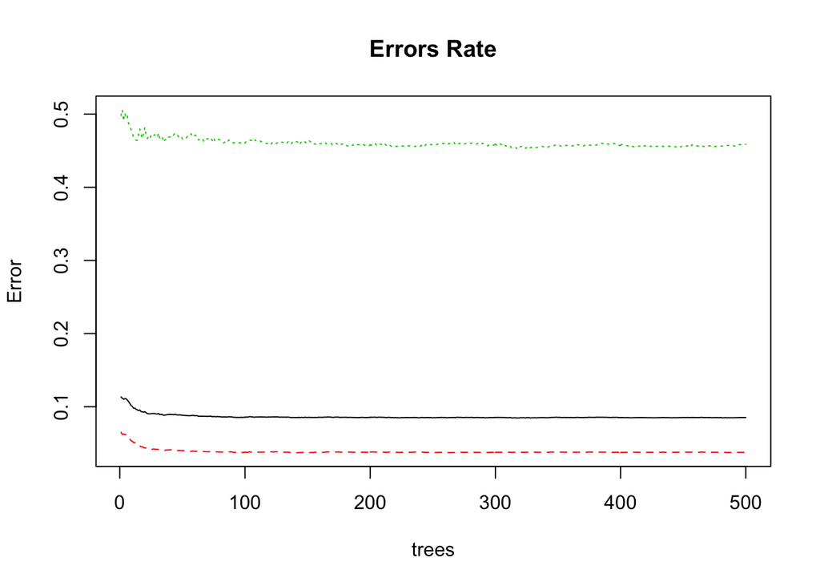

```r
plot(bank_rf, main="Errors Rate")
```

- O la importancia de las variables:

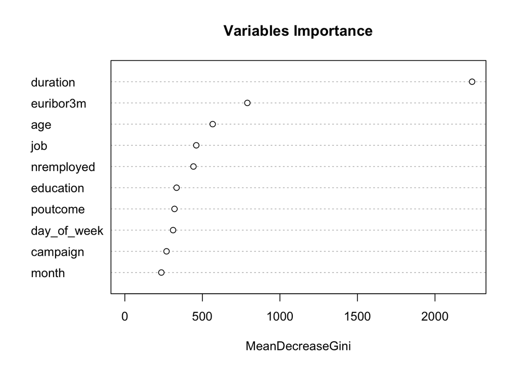

```r
varImpPlot(bank_rf, sort = TRUE, main="Variables Importance",type=2, n.var=10)
```

- Y por último, hacemos nuestras predicciones:

```r
bank_pred_rf <- predict(bank_rf, bank_test)
```

- Y las tabulamos para conocer la precisión:

```r
CrossTable(bank_test$y, bank_pred_rf, prop.chisq=FALSE, prop.c=FALSE, prop.r=FALSE, dnn=c("real", 'pronostico'))
```

```
##
##
##    Cell Contents
## |-------------------------|
## |                       N |
## |         N / Table Total |
## |-------------------------|
##
##
## Total Observations in Table:  4119
##
##
##              | pronostico
##         real |        no |       yes | Row Total |
## -------------|-----------|-----------|-----------|
##           no |      3554 |       119 |      3673 |
##              |     0.863 |     0.029 |           |
## -------------|-----------|-----------|-----------|
##          yes |       237 |       209 |       446 |
##              |     0.058 |     0.051 |           |
## -------------|-----------|-----------|-----------|
## Column Total |      3791 |       328 |      4119 |
## -------------|-----------|-----------|-----------|
##
##
```